# Hola 😀,

Soy **Hesus Garcia** – **"Soy el único Hesus que conoces (y probablemente conocerás) 🌟"** – Sí, como "Jesús", pero con una H que me hace único. Puede sonar raro, pero créeme, ¡no lo olvidarás! Como tu revisor en Triple-Ten, estoy aquí para guiarte y ayudarte a mejorar tu código. Si algo necesita un ajuste, no hay de qué preocuparse; ¡aquí estoy para hacer que tu trabajo brille con todo su potencial! ✨

Cada vez que encuentre un detalle importante en tu código, te lo señalaré para que puedas corregirlo y así te prepares para un ambiente de trabajo real, donde el líder de tu equipo actuaría de manera similar. Si en algún momento no logras solucionar el problema, te daré más detalles para ayudarte en nuestra próxima oportunidad de revisión.

Es importante que cuando encuentres un comentario, **no los muevas, no los modifiques, ni los borres**.

### Formato de Comentarios

Revisaré cuidadosamente cada implementación en tu notebook para asegurar que cumpla con los requisitos y te daré comentarios de acuerdo al siguiente formato:

**Comentario del revisor**

**Éxito** - ¡Excelente trabajo! Esta parte está bien implementada y contribuye significativamente al análisis de datos o al proyecto. Continúa aplicando estas buenas prácticas en futuras secciones.

**Comentario del revisor**

**Atención** ⚠️ - Este código está correcto, pero se puede optimizar. Considera implementar mejoras para que sea más eficiente y fácil de leer. Esto fortalecerá la calidad de tu proyecto.

**Comentario del revisor**

**A resolver** ❗ - Aquí hay un problema o error en el código que es necesario corregir para aprobar esta sección. Por favor, revisa y corrige este punto, ya que es fundamental para la validez del análisis y la precisión de los resultados.

Al final de cada revisión, recibirás un **Comentario General del Revisor** que incluirá:

- **Aspectos positivos:** Un resumen de los puntos fuertes de tu proyecto.
- **Áreas de mejora:** Sugerencias sobre aspectos donde puedes mejorar.
- **Temas adicionales para investigar:** Ideas de temas opcionales que puedes explorar por tu cuenta para desarrollar aún más tus habilidades.

Estos temas adicionales no son obligatorios en esta etapa, pero pueden serte útiles para profundizar en el futuro.

Esta estructura en viñetas facilita la lectura y comprensión de cada parte del comentario final.

También puedes responderme de la siguiente manera si tienes alguna duda o quieres aclarar algo específico:

**Respuesta del estudiante**

Aquí puedes escribir tu respuesta o pregunta sobre el comentario.

**¡Empecemos!** 🚀

# Comentario General del Revisor - 1a iteración

**Comentario del revisor - 1a iteración**

Has desarrollado correctamente las principales etapas del análisis, conectando el comportamiento de los usuarios, las ventas y las métricas de marketing para apoyar la toma de decisiones. **El proyecto está aprobado con oportunidades de mejora.**

**Puntos positivos:**

- Preparaste correctamente los datasets, ajustando los nombres de las columnas y convirtiendo las variables temporales al tipo de dato adecuado.
- Analizaste la actividad de los usuarios mediante DAU, WAU, MAU, sesiones y Sticky Factor, obteniendo métricas como un DAU promedio de 907.99 usuarios.
- Estudiaste el comportamiento de compra mediante el tiempo de conversión, número de pedidos, AOV y LTV por cohortes. El AOV general obtenido fue de aproximadamente 5.00 por pedido.
- Realizaste un buen análisis de los gastos de marketing y del CAC para las diferentes fuentes de adquisición.
- Comparaste la rentabilidad mediante ROMI e identificaste claramente diferencias importantes entre las fuentes, destacando el ROMI positivo de la fuente 1 (49.24 %) frente al resultado negativo de la fuente 3 (-61.43 %).
- Las conclusiones relacionan correctamente CAC, LTV y ROMI y muestran una buena comprensión de cómo estas métricas pueden utilizarse para optimizar el presupuesto de marketing.

Buen trabajo integrando diferentes métricas de negocio para construir una visión global del desempeño de Showz y formular recomendaciones orientadas a mejorar la eficiencia de la inversión en marketing.

Actividad I - Preparación de Datos Cargar los tres datasets (visits_log_us.csv, orders_log_us.csv, costs_us.csv) en variables Validar los tipos de datos de cada columna (especialmente las fechas) Convertir columnas de fecha a datetime Revisar nombres de columnas y dejarlos en un formato limpio (minúsculas, sin espacios, etc.).

```python
import pandas as pd
import numpy as np
import matplotlib.pyplot as plt

# Cargar los datasets
visits = pd.read_csv('/datasets/visits_log_us.csv')
orders = pd.read_csv('/datasets/orders_log_us.csv')
costs = pd.read_csv('/datasets/costs_us.csv')

# Mostrar las primeras filas de cada dataset
print('VISITS')
display(visits.head())

print('ORDERS')
display(orders.head())

print('COSTS')
display(costs.head())
```

```
VISITS
```

|  | Device | End Ts | Source Id | Start Ts | Uid |
| --- | --- | --- | --- | --- | --- |
| 0 | touch | 2017-12-20 17:38:00 | 4 | 2017-12-20 17:20:00 | 16879256277535980062 |
| 1 | desktop | 2018-02-19 17:21:00 | 2 | 2018-02-19 16:53:00 | 104060357244891740 |
| 2 | touch | 2017-07-01 01:54:00 | 5 | 2017-07-01 01:54:00 | 7459035603376831527 |
| 3 | desktop | 2018-05-20 11:23:00 | 9 | 2018-05-20 10:59:00 | 16174680259334210214 |
| 4 | desktop | 2017-12-27 14:06:00 | 3 | 2017-12-27 14:06:00 | 9969694820036681168 |

```
ORDERS
```

|  | Buy Ts | Revenue | Uid |
| --- | --- | --- | --- |
| 0 | 2017-06-01 00:10:00 | 17.00 | 10329302124590727494 |
| 1 | 2017-06-01 00:25:00 | 0.55 | 11627257723692907447 |
| 2 | 2017-06-01 00:27:00 | 0.37 | 17903680561304213844 |
| 3 | 2017-06-01 00:29:00 | 0.55 | 16109239769442553005 |
| 4 | 2017-06-01 07:58:00 | 0.37 | 14200605875248379450 |

```
COSTS
```

|  | source_id | dt | costs |
| --- | --- | --- | --- |
| 0 | 1 | 2017-06-01 | 75.20 |
| 1 | 1 | 2017-06-02 | 62.25 |
| 2 | 1 | 2017-06-03 | 36.53 |
| 3 | 1 | 2017-06-04 | 55.00 |
| 4 | 1 | 2017-06-05 | 57.08 |

```python
# Convertir nombres a minúsculas y reemplazar espacios por guiones bajos
visits.columns = visits.columns.str.lower().str.replace(' ', '_')
orders.columns = orders.columns.str.lower().str.replace(' ', '_')
costs.columns = costs.columns.str.lower().str.replace(' ', '_')

# validar los cambios
print('Columnas de visits:', visits.columns.tolist())
print('Columnas de orders:', orders.columns.tolist())
print('Columnas de costs:', costs.columns.tolist())
```

```
Columnas de visits: ['device', 'end_ts', 'source_id', 'start_ts', 'uid']
Columnas de orders: ['buy_ts', 'revenue', 'uid']
Columnas de costs: ['source_id', 'dt', 'costs']
```

```python
# Convertir las columnas de fecha y hora al tipo datetime
visits['start_ts'] = pd.to_datetime(visits['start_ts'])
visits['end_ts'] = pd.to_datetime(visits['end_ts'])

orders['buy_ts'] = pd.to_datetime(orders['buy_ts'])

costs['dt'] = pd.to_datetime(costs['dt'])

# Validar los tipos de datos
print('Tipos de datos de visits:')
print(visits.dtypes)

print('\nTipos de datos de orders:')
print(orders.dtypes)

print('\nTipos de datos de costs:')
print(costs.dtypes)
```

```
Tipos de datos de visits:
device               object
end_ts       datetime64[ns]
source_id             int64
start_ts     datetime64[ns]
uid                  uint64
dtype: object

Tipos de datos de orders:
buy_ts     datetime64[ns]
revenue           float64
uid                uint64
dtype: object

Tipos de datos de costs:
source_id             int64
dt           datetime64[ns]
costs               float64
dtype: object
```

Conclusión de la Actividad I - Preparación de Datos Los datos fueron cargados y preparados correctamente. Se corrigieron los tipos de datos, especialmente las fechas, y se limpiaron los nombres de las columnas. Con esto, los datasets están listos para realizar el análisis.

Actividad II - Visitas En esta sección analizaremos cómo utilizan los usuarios el servicio. Calcularemos los usuarios activos diarios (DAU), semanales (WAU) y mensuales (MAU), el número de sesiones por día, la duración promedio de las sesiones y la frecuencia con la que los usuarios regresan al servicio.

**Comentario del revisor**

**Éxito** - La preparación de los datos está correctamente realizada. Cargaste los tres datasets, estandarizaste los nombres de las columnas y convertiste adecuadamente las variables de fecha y hora a `datetime`, validando además los tipos resultantes.

La conclusión resume bien esta etapa y deja los datos preparados para comenzar el análisis de visitas.

```python
# Crear columnas auxiliares para realizar los análisis temporales

visits['session_day'] = visits['start_ts'].dt.date
visits['session_week'] = visits['start_ts'].dt.to_period('W').apply(lambda x: x.start_time)
visits['session_month'] = visits['start_ts'].dt.to_period('M').dt.to_timestamp()

# Calcular la duración de cada sesión en segundos
visits['session_duration'] = (
    visits['end_ts'] - visits['start_ts']
).dt.total_seconds()

# Revisar el resultado
display(visits.head())
```

|  | device | end_ts | source_id | start_ts | uid | session_day | session_week | session_month | session_duration |
| --- | --- | --- | --- | --- | --- | --- | --- | --- | --- |
| 0 | touch | 2017-12-20 17:38:00 | 4 | 2017-12-20 17:20:00 | 16879256277535980062 | 2017-12-20 | 2017-12-18 | 2017-12-01 | 1080.0 |
| 1 | desktop | 2018-02-19 17:21:00 | 2 | 2018-02-19 16:53:00 | 104060357244891740 | 2018-02-19 | 2018-02-19 | 2018-02-01 | 1680.0 |
| 2 | touch | 2017-07-01 01:54:00 | 5 | 2017-07-01 01:54:00 | 7459035603376831527 | 2017-07-01 | 2017-06-26 | 2017-07-01 | 0.0 |
| 3 | desktop | 2018-05-20 11:23:00 | 9 | 2018-05-20 10:59:00 | 16174680259334210214 | 2018-05-20 | 2018-05-14 | 2018-05-01 | 1440.0 |
| 4 | desktop | 2017-12-27 14:06:00 | 3 | 2017-12-27 14:06:00 | 9969694820036681168 | 2017-12-27 | 2017-12-25 | 2017-12-01 | 0.0 |

```python
# Calcular DAU: usuarios únicos por día
dau = visits.groupby('session_day')['uid'].nunique()

print('DAU promedio:', round(dau.mean(), 2))
display(dau.head(10))
```

```
DAU promedio: 907.99
```

```
session_day
2017-06-01    605
2017-06-02    608
2017-06-03    445
2017-06-04    476
2017-06-05    820
2017-06-06    797
2017-06-07    699
2017-06-08    868
2017-06-09    695
2017-06-10    350
Name: uid, dtype: int64
```

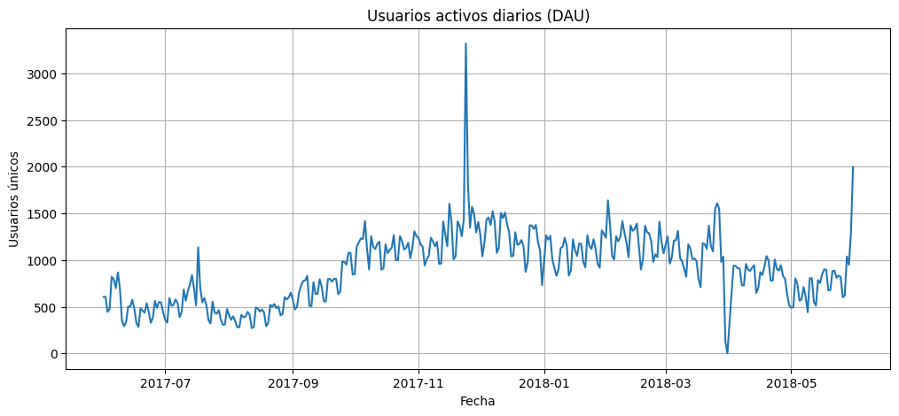

```python
# Gráfico del DAU a lo largo del tiempo
dau.plot(figsize=(12, 5))

plt.title('Usuarios activos diarios (DAU)')
plt.xlabel('Fecha')
plt.ylabel('Usuarios únicos')
plt.grid(True)
plt.show()
```

```python
# Calcular WAU: usuarios únicos por semana
wau = visits.groupby('session_week')['uid'].nunique()

print('WAU promedio:', round(wau.mean(), 2))
display(wau.head(10))
```

```
WAU promedio: 5716.25
```

```
session_week
2017-05-29    2021
2017-06-05    4129
2017-06-12    2812
2017-06-19    2878
2017-06-26    3064
2017-07-03    3294
2017-07-10    4355
2017-07-17    3841
2017-07-24    2655
2017-07-31    2364
Name: uid, dtype: int64
```

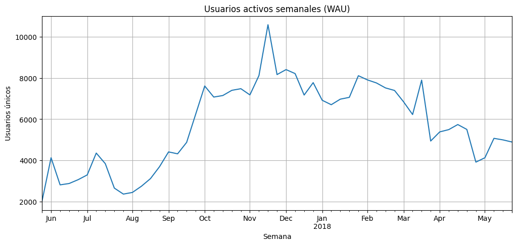

```python
# Gráfico del WAU
wau.plot(figsize=(12, 5))

plt.title('Usuarios activos semanales (WAU)')
plt.xlabel('Semana')
plt.ylabel('Usuarios únicos')
plt.grid(True)
plt.show()
```

```python
# Calcular MAU: usuarios únicos por mes
mau = visits.groupby('session_month')['uid'].nunique()

print('MAU promedio:', round(mau.mean(), 2))
display(mau)
```

```
MAU promedio: 23228.42
```

```
session_month
2017-06-01    13259
2017-07-01    14183
2017-08-01    11631
2017-09-01    18975
2017-10-01    29692
2017-11-01    32797
2017-12-01    31557
2018-01-01    28716
2018-02-01    28749
2018-03-01    27473
2018-04-01    21008
2018-05-01    20701
Name: uid, dtype: int64
```

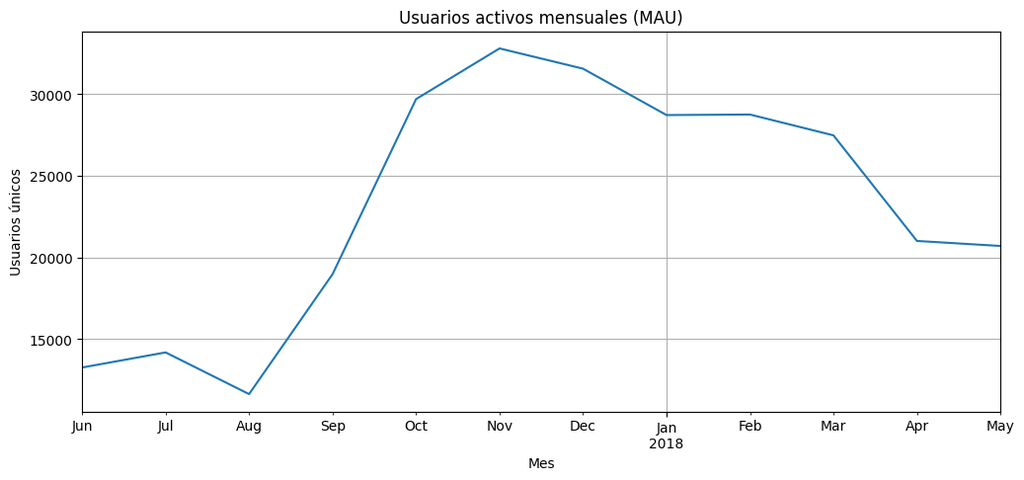

```python
# Gráfico del MAU

mau.plot(figsize=(12, 5))

plt.title('Usuarios activos mensuales (MAU)')
plt.xlabel('Mes')
plt.ylabel('Usuarios únicos')
plt.grid(True)
plt.show()
```

```python
# Número total de sesiones por día
sessions_per_day = visits.groupby('session_day').size()

print('Promedio de sesiones por día:', round(sessions_per_day.mean(), 2))
display(sessions_per_day.head(10))
```

```
Promedio de sesiones por día: 987.36
```

```
session_day
2017-06-01    664
2017-06-02    658
2017-06-03    477
2017-06-04    510
2017-06-05    893
2017-06-06    875
2017-06-07    788
2017-06-08    939
2017-06-09    755
2017-06-10    375
dtype: int64
```

```python
# Grafico de sesiones por dia
sessions_per_day.plot(figsize=(12, 5))

plt.title('Número de sesiones por día')
plt.xlabel('Fecha')
plt.ylabel('Número de sesiones')
plt.grid(True)
plt.show()
```

[output not shown]

```python
# Calcular ASL en segundos
asl = visits['session_duration'].mean()

print('ASL en segundos:', round(asl, 2))
print('ASL en minutos:', round(asl / 60, 2))
```

```
ASL en segundos: 643.03
ASL en minutos: 10.72
```

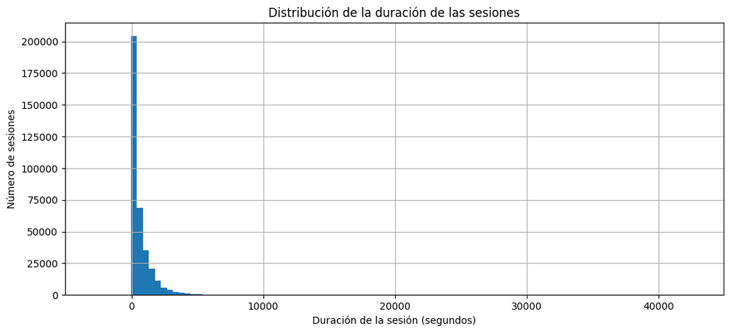

```python
# Histograma de duración de las sesiones
visits['session_duration'].hist(bins=100, figsize=(12, 5))

plt.title('Distribución de la duración de las sesiones')
plt.xlabel('Duración de la sesión (segundos)')
plt.ylabel('Número de sesiones')
plt.show()
```

**Comentario del revisor**

**Éxito** - El análisis de actividad de los usuarios está bien planteado. Calculaste correctamente DAU, WAU y MAU, además del número de sesiones por día y la duración promedio de las sesiones, acompañando las métricas con gráficos que permiten observar su evolución y distribución.

Como **sugerencia de mejora**, cuando cierres esta parte puedes añadir una breve interpretación de los principales patrones observados en los gráficos para complementar los cálculos realizados.

```python
# Calcular Sticky Factor utilizando el promedio de DAU y MAU
#El Sticky Factor indica qué tan frecuentemente los usuarios regresan al servicio.
sticky_factor = dau.mean() / mau.mean() * 100

print('Sticky Factor:', round(sticky_factor, 2), '%')
```

```
Sticky Factor: 3.91 %
```

```python
# ==========================================
# FRECUENCIA DE RETORNO - STICKY FACTOR
# ==========================================

# DAU: usuarios únicos por día
dau_total = visits.groupby('session_day')['uid'].nunique().mean()

# WAU: usuarios únicos por semana
wau_total = visits.groupby('session_week')['uid'].nunique().mean()

# MAU: usuarios únicos por mes
mau_total = visits.groupby('session_month')['uid'].nunique().mean()

# Mostrar las métricas utilizadas
print('DAU promedio:', round(dau_total, 2))
print('WAU promedio:', round(wau_total, 2))
print('MAU promedio:', round(mau_total, 2))

# Sticky Factor diario/mensual
sticky_factor_daily = dau_total / mau_total

# Sticky Factor semanal/mensual
sticky_factor_weekly = wau_total / mau_total

# Mostrar resultados
print('\nSticky Factor diario/mensual:',
      round(sticky_factor_daily, 4))

print('Sticky Factor semanal/mensual:',
      round(sticky_factor_weekly, 4))

# Mostrar también como porcentaje
print('\nSticky Factor DAU/MAU:',
      round(sticky_factor_daily * 100, 2), '%')

print('Sticky Factor WAU/MAU:',
      round(sticky_factor_weekly * 100, 2), '%')
```

```
DAU promedio: 907.99
WAU promedio: 5716.25
MAU promedio: 23228.42

Sticky Factor diario/mensual: 0.0391
Sticky Factor semanal/mensual: 0.2461

Sticky Factor DAU/MAU: 3.91 %
Sticky Factor WAU/MAU: 24.61 %
```

Conclusión de la Actividad II - Visitas El análisis permitió conocer el nivel de actividad de los usuarios mediante DAU, WAU y MAU, además del número de sesiones y su duración promedio. El Sticky Factor permitió evaluar la frecuencia con la que los usuarios regresan al servicio. Estas métricas ayudan a comprender el nivel de uso y engagement de los usuarios de Showz.

Actividad III : Ventas En esta sección analizaremos el comportamiento de compra de los usuarios de Showz. Calcularemos el tiempo que transcurre desde la primera visita hasta la primera compra, el número de pedidos, el tamaño promedio de las compras y el valor de vida del cliente (LTV).

**Comentario del revisor**

**Éxito** - La frecuencia de retorno está correctamente abordada mediante los Sticky Factors DAU/MAU y WAU/MAU, obteniendo 3.91% y 24.61%, respectivamente. Esto complementa adecuadamente las métricas de actividad calculadas previamente.

```python
# Primera visita de cada usuario
first_visit = (
    visits.groupby('uid')['start_ts']
    .min()
    .reset_index()
)

first_visit.columns = ['uid', 'first_visit_ts']

display(first_visit.head())
```

|  | uid | first_visit_ts |
| --- | --- | --- |
| 0 | 11863502262781 | 2018-03-01 17:27:00 |
| 1 | 49537067089222 | 2018-02-06 15:55:00 |
| 2 | 297729379853735 | 2017-06-07 18:47:00 |
| 3 | 313578113262317 | 2017-09-18 22:49:00 |
| 4 | 325320750514679 | 2017-09-30 14:29:00 |

```python
# Primera compra de cada usuario
first_order = (
    orders.groupby('uid')['buy_ts']
    .min()
    .reset_index()
)

first_order.columns = ['uid', 'first_order_ts']

display(first_order.head())
```

|  | uid | first_order_ts |
| --- | --- | --- |
| 0 | 313578113262317 | 2018-01-03 21:51:00 |
| 1 | 1575281904278712 | 2017-06-03 10:13:00 |
| 2 | 2429014661409475 | 2017-10-11 18:33:00 |
| 3 | 2464366381792757 | 2018-01-28 15:54:00 |
| 4 | 2551852515556206 | 2017-11-24 10:14:00 |

```python
# Unir la primera visita con la primera compra
conversion = first_visit.merge(
    first_order,
    on='uid',
    how='inner'
)

display(conversion.head())
```

|  | uid | first_visit_ts | first_order_ts |
| --- | --- | --- | --- |
| 0 | 313578113262317 | 2017-09-18 22:49:00 | 2018-01-03 21:51:00 |
| 1 | 1575281904278712 | 2017-06-03 10:13:00 | 2017-06-03 10:13:00 |
| 2 | 2429014661409475 | 2017-10-11 17:14:00 | 2017-10-11 18:33:00 |
| 3 | 2464366381792757 | 2018-01-27 20:10:00 | 2018-01-28 15:54:00 |
| 4 | 2551852515556206 | 2017-11-24 10:14:00 | 2017-11-24 10:14:00 |

```python
# Calcular tiempo desde la primera visita hasta la primera compra
conversion['conversion_time'] = (
    conversion['first_order_ts'] - conversion['first_visit_ts']
)

# Convertir a días
conversion['conversion_days'] = (
    conversion['conversion_time'].dt.total_seconds() / 86400
)

display(conversion.head())
```

|  | uid | first_visit_ts | first_order_ts | conversion_time | conversion_days |
| --- | --- | --- | --- | --- | --- |
| 0 | 313578113262317 | 2017-09-18 22:49:00 | 2018-01-03 21:51:00 | 106 days 23:02:00 | 106.959722 |
| 1 | 1575281904278712 | 2017-06-03 10:13:00 | 2017-06-03 10:13:00 | 0 days 00:00:00 | 0.000000 |
| 2 | 2429014661409475 | 2017-10-11 17:14:00 | 2017-10-11 18:33:00 | 0 days 01:19:00 | 0.054861 |
| 3 | 2464366381792757 | 2018-01-27 20:10:00 | 2018-01-28 15:54:00 | 0 days 19:44:00 | 0.822222 |
| 4 | 2551852515556206 | 2017-11-24 10:14:00 | 2017-11-24 10:14:00 | 0 days 00:00:00 | 0.000000 |

```python
# Estadisticas
print('Tiempo promedio hasta la primera compra:',
      round(conversion['conversion_days'].mean(), 2), 'días')

print('Mediana del tiempo de conversión:',
      round(conversion['conversion_days'].median(), 2), 'días')

print('Percentil 90:',
      round(conversion['conversion_days'].quantile(0.90), 2), 'días')
```

```
Tiempo promedio hasta la primera compra: 16.9 días
Mediana del tiempo de conversión: 0.01 días
Percentil 90: 58.08 días
```

**Comentario del revisor**

**Éxito** - El cálculo del tiempo desde la primera visita hasta la primera compra está correctamente planteado. Identificaste la primera visita y la primera compra de cada usuario y obtuviste métricas útiles como promedio, mediana y percentil 90.

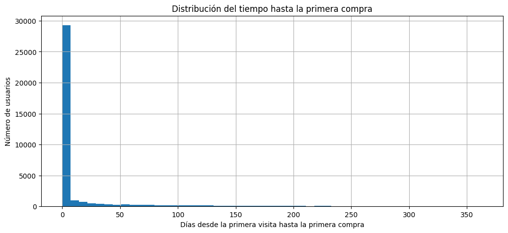

```python
# Histograma
conversion['conversion_days'].hist(bins=50, figsize=(12, 5))

plt.title('Distribución del tiempo hasta la primera compra')
plt.xlabel('Días desde la primera visita hasta la primera compra')
plt.ylabel('Número de usuarios')
plt.show()
```

```python
# Número total de pedidos
total_orders = orders.shape[0]

print('Número total de pedidos:', total_orders)
```

```
Número total de pedidos: 50415
```

```python
# Número de pedidos por usuario
orders_per_user = orders.groupby('uid').size()

print('Promedio de pedidos por usuario:',
      round(orders_per_user.mean(), 2))

print('Mediana de pedidos por usuario:',
      round(orders_per_user.median(), 2))
```

```
Promedio de pedidos por usuario: 1.38
Mediana de pedidos por usuario: 1.0
```

```
order_month
2017-06-01    2354
2017-07-01    2363
2017-08-01    1807
2017-09-01    3387
2017-10-01    5679
2017-11-01    5659
2017-12-01    6218
2018-01-01    4721
2018-02-01    5281
2018-03-01    5326
2018-04-01    3273
2018-05-01    4346
2018-06-01       1
dtype: int64
```

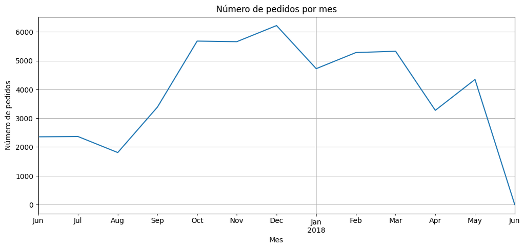

```python
# Pedidos de largo tiempo
orders['order_month'] = orders['buy_ts'].dt.to_period('M').dt.to_timestamp()
orders_by_month = orders.groupby('order_month').size()
display(orders_by_month)

# Grafico
orders_by_month.plot(figsize=(12, 5))
plt.title('Número de pedidos por mes')
plt.xlabel('Mes')
plt.ylabel('Número de pedidos')
plt.grid(True)
plt.show()
```

```python
# Tamaño promedio de compra - AOV (Average Order Value) representa cuánto dinero genera, en promedio, cada pedido)
# (Formula) AOV = ingresos totales / número de pedidos

# Calcular el tamaño promedio de compra
total_revenue = orders['revenue'].sum()

aov = total_revenue / total_orders

print('Ingresos totales:', round(total_revenue, 2))
print('Número de pedidos:', total_orders)
print('AOV:', round(aov, 2))
```

```
Ingresos totales: 252057.2
Número de pedidos: 50415
AOV: 5.0
```

```
order_month
2017-06-01    4.060106
2017-07-01    5.306589
2017-08-01    4.847139
2017-09-01    5.416448
2017-10-01    4.928280
2017-11-01    4.783518
2017-12-01    5.852139
2018-01-01    4.112927
2018-02-01    4.840095
2018-03-01    5.413930
2018-04-01    5.150645
2018-05-01    4.771279
2018-06-01    3.420000
Name: revenue, dtype: float64
```

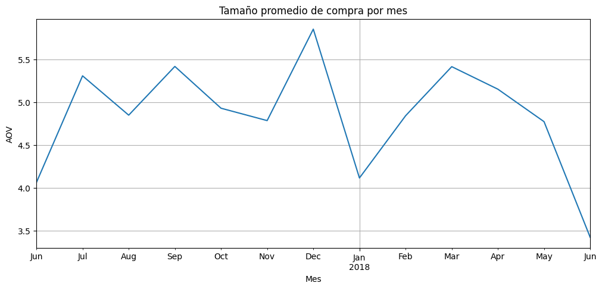

```python
# AOV por mes
aov_by_month = orders.groupby('order_month')['revenue'].mean()

display(aov_by_month)

#Grafica
aov_by_month.plot(figsize=(12, 5))

plt.title('Tamaño promedio de compra por mes')
plt.xlabel('Mes')
plt.ylabel('AOV')
plt.grid(True)
plt.show()
```

**Comentario del revisor**

**Éxito** - El análisis de ventas avanza correctamente. Calculaste el número total de pedidos, la frecuencia de compra por usuario y el tamaño promedio de compra (AOV), además de analizar su evolución mensual mediante gráficos.

Como **sugerencia de mejora**, puedes complementar esta parte con una breve interpretación de los resultados, por ejemplo destacando los meses con mayor volumen de pedidos y cómo varía el AOV a lo largo del tiempo.

```python
# LTV — Lifetime Value
# El LTV indica cuánto ingreso genera, en promedio, un cliente durante un período determinado.

# Obtener el primer pedido de cada cliente
first_order = (
    orders.groupby('uid')['buy_ts']
    .min()
    .reset_index()
)

first_order.columns = ['uid', 'first_order_ts']

# Crear el mes de la primera compra
first_order['cohort_month'] = (
    first_order['first_order_ts']
    .dt.to_period('M')
    .dt.to_timestamp()
)

display(first_order.head())
```

|  | uid | first_order_ts | cohort_month |
| --- | --- | --- | --- |
| 0 | 313578113262317 | 2018-01-03 21:51:00 | 2018-01-01 |
| 1 | 1575281904278712 | 2017-06-03 10:13:00 | 2017-06-01 |
| 2 | 2429014661409475 | 2017-10-11 18:33:00 | 2017-10-01 |
| 3 | 2464366381792757 | 2018-01-28 15:54:00 | 2018-01-01 |
| 4 | 2551852515556206 | 2017-11-24 10:14:00 | 2017-11-01 |

```python
# Añadir la cohorte a cada pedido
orders_cohort = orders.merge(
    first_order[['uid', 'cohort_month']],
    on='uid',
    how='left'
)

# Crear el mes de cada pedido
orders_cohort['order_month'] = (
    orders_cohort['buy_ts']
    .dt.to_period('M')
    .dt.to_timestamp()
)

display(orders_cohort.head())
```

|  | buy_ts | revenue | uid | order_month | cohort_month |
| --- | --- | --- | --- | --- | --- |
| 0 | 2017-06-01 00:10:00 | 17.00 | 10329302124590727494 | 2017-06-01 | 2017-06-01 |
| 1 | 2017-06-01 00:25:00 | 0.55 | 11627257723692907447 | 2017-06-01 | 2017-06-01 |
| 2 | 2017-06-01 00:27:00 | 0.37 | 17903680561304213844 | 2017-06-01 | 2017-06-01 |
| 3 | 2017-06-01 00:29:00 | 0.55 | 16109239769442553005 | 2017-06-01 | 2017-06-01 |
| 4 | 2017-06-01 07:58:00 | 0.37 | 14200605875248379450 | 2017-06-01 | 2017-06-01 |

```python
# Calcular los ingresos por cohorte y mes
cohort_revenue = (
    orders_cohort
    .groupby(['cohort_month', 'order_month'])['revenue']
    .sum()
    .unstack()
    .fillna(0)
)

display(cohort_revenue)
```

| order_month cohort_month | 2017-06-01 | 2017-07-01 | 2017-08-01 | 2017-09-01 | 2017-10-01 | 2017-11-01 | 2017-12-01 | 2018-01-01 | 2018-02-01 | 2018-03-01 | 2018-04-01 | 2018-05-01 | 2018-06-01 |
| --- | --- | --- | --- | --- | --- | --- | --- | --- | --- | --- | --- | --- | --- |
| 2017-06-01 | 9557.49 | 981.82 | 885.34 | 1931.30 | 2068.58 | 1487.92 | 1922.74 | 1176.56 | 1119.15 | 1225.51 | 1155.66 | 519.62 | 0.00 |
| 2017-07-01 | 0.00 | 11557.65 | 644.61 | 1199.05 | 690.31 | 339.97 | 300.08 | 231.16 | 272.72 | 310.05 | 282.96 | 299.36 | 0.00 |
| 2017-08-01 | 0.00 | 0.00 | 7228.83 | 646.63 | 628.12 | 536.05 | 676.85 | 388.45 | 288.61 | 554.86 | 400.33 | 257.53 | 0.00 |
| 2017-09-01 | 0.00 | 0.00 | 0.00 | 14568.53 | 2884.49 | 1344.52 | 10261.52 | 1033.84 | 1670.08 | 1810.85 | 627.57 | 474.92 | 0.00 |
| 2017-10-01 | 0.00 | 0.00 | 0.00 | 0.00 | 21716.20 | 2325.21 | 830.65 | 682.01 | 657.77 | 522.37 | 368.10 | 501.14 | 0.00 |
| 2017-11-01 | 0.00 | 0.00 | 0.00 | 0.00 | 0.00 | 21036.26 | 1629.27 | 814.39 | 1326.13 | 604.04 | 219.88 | 469.02 | 0.00 |
| 2017-12-01 | 0.00 | 0.00 | 0.00 | 0.00 | 0.00 | 0.00 | 20767.49 | 1141.22 | 4054.70 | 4669.10 | 1371.57 | 1481.66 | 0.00 |
| 2018-01-01 | 0.00 | 0.00 | 0.00 | 0.00 | 0.00 | 0.00 | 0.00 | 13949.50 | 994.22 | 1026.34 | 481.59 | 211.48 | 0.00 |
| 2018-02-01 | 0.00 | 0.00 | 0.00 | 0.00 | 0.00 | 0.00 | 0.00 | 0.00 | 15177.16 | 1015.98 | 286.66 | 270.70 | 0.00 |
| 2018-03-01 | 0.00 | 0.00 | 0.00 | 0.00 | 0.00 | 0.00 | 0.00 | 0.00 | 0.00 | 17095.49 | 1063.05 | 1114.87 | 0.00 |
| 2018-04-01 | 0.00 | 0.00 | 0.00 | 0.00 | 0.00 | 0.00 | 0.00 | 0.00 | 0.00 | 0.00 | 10600.69 | 1209.92 | 0.00 |
| 2018-05-01 | 0.00 | 0.00 | 0.00 | 0.00 | 0.00 | 0.00 | 0.00 | 0.00 | 0.00 | 0.00 | 0.00 | 13925.76 | 0.00 |
| 2018-06-01 | 0.00 | 0.00 | 0.00 | 0.00 | 0.00 | 0.00 | 0.00 | 0.00 | 0.00 | 0.00 | 0.00 | 0.00 | 3.42 |

```python
# Ingresos acumulados por cohorte
cumulative_revenue = cohort_revenue.cumsum(axis=1)

display(cumulative_revenue)
```

| order_month cohort_month | 2017-06-01 | 2017-07-01 | 2017-08-01 | 2017-09-01 | 2017-10-01 | 2017-11-01 | 2017-12-01 | 2018-01-01 | 2018-02-01 | 2018-03-01 | 2018-04-01 | 2018-05-01 | 2018-06-01 |
| --- | --- | --- | --- | --- | --- | --- | --- | --- | --- | --- | --- | --- | --- |
| 2017-06-01 | 9557.49 | 10539.31 | 11424.65 | 13355.95 | 15424.53 | 16912.45 | 18835.19 | 20011.75 | 21130.90 | 22356.41 | 23512.07 | 24031.69 | 24031.69 |
| 2017-07-01 | 0.00 | 11557.65 | 12202.26 | 13401.31 | 14091.62 | 14431.59 | 14731.67 | 14962.83 | 15235.55 | 15545.60 | 15828.56 | 16127.92 | 16127.92 |
| 2017-08-01 | 0.00 | 0.00 | 7228.83 | 7875.46 | 8503.58 | 9039.63 | 9716.48 | 10104.93 | 10393.54 | 10948.40 | 11348.73 | 11606.26 | 11606.26 |
| 2017-09-01 | 0.00 | 0.00 | 0.00 | 14568.53 | 17453.02 | 18797.54 | 29059.06 | 30092.90 | 31762.98 | 33573.83 | 34201.40 | 34676.32 | 34676.32 |
| 2017-10-01 | 0.00 | 0.00 | 0.00 | 0.00 | 21716.20 | 24041.41 | 24872.06 | 25554.07 | 26211.84 | 26734.21 | 27102.31 | 27603.45 | 27603.45 |
| 2017-11-01 | 0.00 | 0.00 | 0.00 | 0.00 | 0.00 | 21036.26 | 22665.53 | 23479.92 | 24806.05 | 25410.09 | 25629.97 | 26098.99 | 26098.99 |
| 2017-12-01 | 0.00 | 0.00 | 0.00 | 0.00 | 0.00 | 0.00 | 20767.49 | 21908.71 | 25963.41 | 30632.51 | 32004.08 | 33485.74 | 33485.74 |
| 2018-01-01 | 0.00 | 0.00 | 0.00 | 0.00 | 0.00 | 0.00 | 0.00 | 13949.50 | 14943.72 | 15970.06 | 16451.65 | 16663.13 | 16663.13 |
| 2018-02-01 | 0.00 | 0.00 | 0.00 | 0.00 | 0.00 | 0.00 | 0.00 | 0.00 | 15177.16 | 16193.14 | 16479.80 | 16750.50 | 16750.50 |
| 2018-03-01 | 0.00 | 0.00 | 0.00 | 0.00 | 0.00 | 0.00 | 0.00 | 0.00 | 0.00 | 17095.49 | 18158.54 | 19273.41 | 19273.41 |
| 2018-04-01 | 0.00 | 0.00 | 0.00 | 0.00 | 0.00 | 0.00 | 0.00 | 0.00 | 0.00 | 0.00 | 10600.69 | 11810.61 | 11810.61 |
| 2018-05-01 | 0.00 | 0.00 | 0.00 | 0.00 | 0.00 | 0.00 | 0.00 | 0.00 | 0.00 | 0.00 | 0.00 | 13925.76 | 13925.76 |
| 2018-06-01 | 0.00 | 0.00 | 0.00 | 0.00 | 0.00 | 0.00 | 0.00 | 0.00 | 0.00 | 0.00 | 0.00 | 0.00 | 3.42 |

```python
# Numero de Clientes por Cohorte

cohort_users = (
    first_order
    .groupby('cohort_month')['uid']
    .nunique()
)

display(cohort_users)
```

```
cohort_month
2017-06-01    2023
2017-07-01    1923
2017-08-01    1370
2017-09-01    2581
2017-10-01    4340
2017-11-01    4081
2017-12-01    4383
2018-01-01    3373
2018-02-01    3651
2018-03-01    3533
2018-04-01    2276
2018-05-01    2988
2018-06-01       1
Name: uid, dtype: int64
```

**Comentario del revisor**

**Atención** - La construcción de las cohortes está bien realizada: identificaste el mes de la primera compra, calculaste los ingresos por cohorte y obtuviste correctamente el número de clientes de cada una.

```python
# Calcular LTV acumulado por cohorte

ltv = cumulative_revenue.div(cohort_users, axis=0)

display(ltv.round(2))
```

| order_month cohort_month | 2017-06-01 | 2017-07-01 | 2017-08-01 | 2017-09-01 | 2017-10-01 | 2017-11-01 | 2017-12-01 | 2018-01-01 | 2018-02-01 | 2018-03-01 | 2018-04-01 | 2018-05-01 | 2018-06-01 |
| --- | --- | --- | --- | --- | --- | --- | --- | --- | --- | --- | --- | --- | --- |
| 2017-06-01 | 4.72 | 5.21 | 5.65 | 6.60 | 7.62 | 8.36 | 9.31 | 9.89 | 10.45 | 11.05 | 11.62 | 11.88 | 11.88 |
| 2017-07-01 | 0.00 | 6.01 | 6.35 | 6.97 | 7.33 | 7.50 | 7.66 | 7.78 | 7.92 | 8.08 | 8.23 | 8.39 | 8.39 |
| 2017-08-01 | 0.00 | 0.00 | 5.28 | 5.75 | 6.21 | 6.60 | 7.09 | 7.38 | 7.59 | 7.99 | 8.28 | 8.47 | 8.47 |
| 2017-09-01 | 0.00 | 0.00 | 0.00 | 5.64 | 6.76 | 7.28 | 11.26 | 11.66 | 12.31 | 13.01 | 13.25 | 13.44 | 13.44 |
| 2017-10-01 | 0.00 | 0.00 | 0.00 | 0.00 | 5.00 | 5.54 | 5.73 | 5.89 | 6.04 | 6.16 | 6.24 | 6.36 | 6.36 |
| 2017-11-01 | 0.00 | 0.00 | 0.00 | 0.00 | 0.00 | 5.15 | 5.55 | 5.75 | 6.08 | 6.23 | 6.28 | 6.40 | 6.40 |
| 2017-12-01 | 0.00 | 0.00 | 0.00 | 0.00 | 0.00 | 0.00 | 4.74 | 5.00 | 5.92 | 6.99 | 7.30 | 7.64 | 7.64 |
| 2018-01-01 | 0.00 | 0.00 | 0.00 | 0.00 | 0.00 | 0.00 | 0.00 | 4.14 | 4.43 | 4.73 | 4.88 | 4.94 | 4.94 |
| 2018-02-01 | 0.00 | 0.00 | 0.00 | 0.00 | 0.00 | 0.00 | 0.00 | 0.00 | 4.16 | 4.44 | 4.51 | 4.59 | 4.59 |
| 2018-03-01 | 0.00 | 0.00 | 0.00 | 0.00 | 0.00 | 0.00 | 0.00 | 0.00 | 0.00 | 4.84 | 5.14 | 5.46 | 5.46 |
| 2018-04-01 | 0.00 | 0.00 | 0.00 | 0.00 | 0.00 | 0.00 | 0.00 | 0.00 | 0.00 | 0.00 | 4.66 | 5.19 | 5.19 |
| 2018-05-01 | 0.00 | 0.00 | 0.00 | 0.00 | 0.00 | 0.00 | 0.00 | 0.00 | 0.00 | 0.00 | 0.00 | 4.66 | 4.66 |
| 2018-06-01 | 0.00 | 0.00 | 0.00 | 0.00 | 0.00 | 0.00 | 0.00 | 0.00 | 0.00 | 0.00 | 0.00 | 0.00 | 3.42 |

```python
# LTV acumulado después de 6 meses
m6_cum_ltv = ltv.iloc[:, :6].iloc[:, -1].mean()

print('LTV acumulado promedio a 6 meses:', round(m6_cum_ltv, 2))
```

```
LTV acumulado promedio a 6 meses: 3.11
```

Interpretación del AOV El AOV representa el ingreso promedio generado por cada pedido. Un AOV más elevado significa que, en promedio, cada transacción genera mayores ingresos para Showz. La evolución mensual permite identificar períodos en los que los clientes realizan compras de mayor o menor valor.

Conclusión de la Actividad III - Ventas

El análisis de ventas permitió conocer el comportamiento de los usuarios desde su primera visita hasta que realizan una compra y el valor que generan para Showz.

El tiempo de conversión muestra cuánto tardan los usuarios en realizar su primera compra después de visitar el servicio. Esta métrica permite evaluar qué tan rápido se convierten los visitantes en clientes.

El número de pedidos permite medir la actividad de compra durante el período analizado y conocer la frecuencia con la que los clientes realizan transacciones.

El AOV (tamaño promedio de compra) permite determinar cuánto ingreso genera, en promedio, cada pedido. Un AOV mayor significa que cada transacción aporta más ingresos a la empresa.

Por último, el LTV permite conocer el valor económico que generan los clientes a lo largo del tiempo. Esta es una métrica especialmente importante para las decisiones de marketing, ya que permite comparar el valor generado por los clientes con el costo de adquirirlos.

En conjunto, estas métricas muestran que no es suficiente analizar únicamente la cantidad de pedidos o el valor promedio de una compra. Para evaluar la rentabilidad de los clientes es necesario considerar también cuánto tardan en convertirse y cuánto valor generan durante su relación con Showz.

Los resultados obtenidos en esta actividad servirán como base para comparar el LTV con el CAC y el ROMI en el análisis de marketing y determinar qué fuentes de adquisición son más rentables para la empresa.

Actividad IV. Marketing

En esta sección analizaremos los gastos de marketing de Showz para determinar cuánto se invierte en cada fuente de adquisición y qué tan rentable es dicha inversión.

Calcularemos el gasto total, el gasto por fuente y su evolución temporal. Posteriormente calcularemos el CAC y el ROMI para comparar la rentabilidad de las diferentes fuentes de adquisición.

**Comentario del revisor**

**Atención** - El cálculo del LTV por cohorte está correctamente planteado y también incluiste una estimación del LTV acumulado a 6 meses.

Para completar esta parte, revisa específicamente cómo estás seleccionando esos seis meses. Actualmente, se toman las primeras seis columnas del calendario general, por lo que no representan seis meses de vida para todas las cohortes.

Conviene alinear las cohortes según los meses transcurridos desde su primera compra para que el LTV a 6 meses sea comparable entre ellas.

```python
# Gasto total de marketing
total_marketing_cost = costs['costs'].sum()

print('Gasto total de marketing:', round(total_marketing_cost, 2))
```

```
Gasto total de marketing: 329131.62
```

```
source_id
3     141321.63
4      61073.60
5      51757.10
2      42806.04
1      20833.27
10      5822.49
9       5517.49
Name: costs, dtype: float64
```

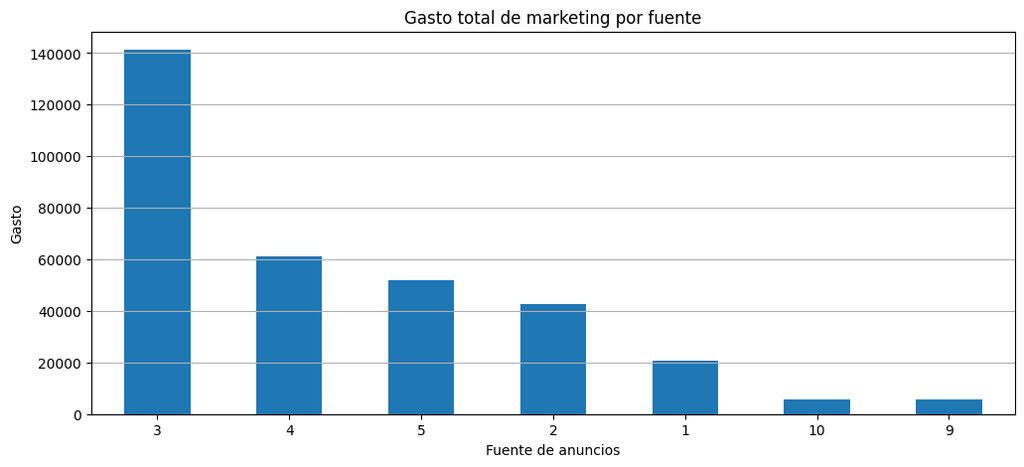

```python
# Gasto total por fuente de anuncios
costs_by_source = (
    costs.groupby('source_id')['costs']
    .sum()
    .sort_values(ascending=False)
)

display(costs_by_source)

#Grafico
costs_by_source.plot(
    kind='bar',
    figsize=(12, 5)
)

plt.title('Gasto total de marketing por fuente')
plt.xlabel('Fuente de anuncios')
plt.ylabel('Gasto')
plt.xticks(rotation=0)
plt.grid(axis='y')
plt.show()
```

Interpretación del gasto por fuente

El gasto de marketing no se distribuye necesariamente de manera uniforme entre las diferentes fuentes de adquisición.

Las fuentes con mayor inversión representan una parte importante del presupuesto de marketing, pero un mayor gasto no significa necesariamente una mayor rentabilidad. Por este motivo, posteriormente compararemos estos gastos con el número de clientes adquiridos y los ingresos generados.

```
cost_month
2017-06-01    18015.00
2017-07-01    18240.59
2017-08-01    14790.54
2017-09-01    24368.91
2017-10-01    36322.88
2017-11-01    37907.88
2017-12-01    38315.35
2018-01-01    33518.52
2018-02-01    32723.03
2018-03-01    30415.27
2018-04-01    22289.38
2018-05-01    22224.27
Name: costs, dtype: float64
```

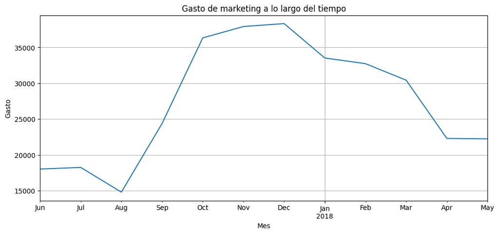

```python
# Gasto de Marketing a largo tiempo

# Crear columna con el mes
costs['cost_month'] = (
    costs['dt']
    .dt.to_period('M')
    .dt.to_timestamp()
)

# Gasto mensual
costs_by_month = (
    costs.groupby('cost_month')['costs']
    .sum()
)

display(costs_by_month)

# Grafico
costs_by_month.plot(
    figsize=(12, 5)
)

plt.title('Gasto de marketing a lo largo del tiempo')
plt.xlabel('Mes')
plt.ylabel('Gasto')
plt.grid(True)
plt.show()
```

**Comentario del revisor**

**Éxito** - El análisis del gasto de marketing está correctamente realizado. Calculaste el gasto total, el gasto por fuente de adquisición y su evolución mensual, cumpliendo con lo solicitado en esta parte del proyecto.

| source_id cost_month | 1 | 2 | 3 | 4 | 5 | 9 | 10 |
| --- | --- | --- | --- | --- | --- | --- | --- |
| 2017-06-01 | 1125.61 | 2427.38 | 7731.65 | 3514.80 | 2616.12 | 285.22 | 314.22 |
| 2017-07-01 | 1072.88 | 2333.11 | 7674.37 | 3529.73 | 2998.14 | 302.54 | 329.82 |
| 2017-08-01 | 951.81 | 1811.05 | 6143.54 | 3217.36 | 2185.28 | 248.93 | 232.57 |
| 2017-09-01 | 1502.01 | 2985.66 | 9963.55 | 5192.26 | 3849.14 | 415.62 | 460.67 |
| 2017-10-01 | 2315.75 | 4845.00 | 15737.24 | 6420.84 | 5767.40 | 609.41 | 627.24 |

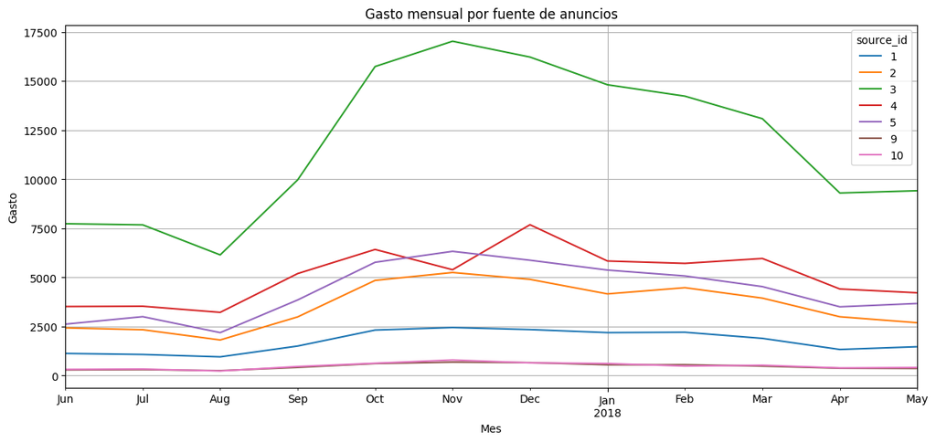

```python
# Gasto mensual por fuente
costs_source_month = (
    costs.groupby(['cost_month', 'source_id'])['costs']
    .sum()
    .unstack(fill_value=0)
)

display(costs_source_month.head())

#Grafico
costs_source_month.plot(
    figsize=(14, 6)
)

plt.title('Gasto mensual por fuente de anuncios')
plt.xlabel('Mes')
plt.ylabel('Gasto')
plt.grid(True)
plt.show()
```

```python
# CAC — Costo de adquisición de clientes
# CAC = Gasto de marketing / Número de clientes adquiridos

# Obtener la primera visita de cada usuario
first_visit_source = (
    visits.sort_values('start_ts')
    .drop_duplicates('uid')[['uid', 'source_id']]
)

display(first_visit_source.head())
```

|  | uid | source_id |
| --- | --- | --- |
| 308527 | 13890188992670018146 | 5 |
| 260646 | 16152015161748786004 | 3 |
| 245715 | 16706502037388497502 | 3 |
| 235930 | 8842918131297115663 | 3 |
| 11727 | 10329302124590727494 | 1 |

```python
# Obtener los usuarios que realizaron al menos una compra
customers = orders[['uid']].drop_duplicates()

# Añadir la fuente de adquisición
customers_source = customers.merge(
    first_visit_source,
    on='uid',
    how='left'
)

display(customers_source.head())
```

|  | uid | source_id |
| --- | --- | --- |
| 0 | 10329302124590727494 | 1 |
| 1 | 11627257723692907447 | 2 |
| 2 | 17903680561304213844 | 2 |
| 3 | 16109239769442553005 | 2 |
| 4 | 14200605875248379450 | 3 |

```python
# Clientes adquiridos por fuente
customers_by_source = (
    customers_source.groupby('source_id')['uid']
    .nunique()
)

display(customers_by_source)
```

```
source_id
1      2899
2      3506
3     10473
4     10296
5      6931
7         1
9      1088
10     1329
Name: uid, dtype: int64
```

| source_id | marketing_cost | customers | cac |
| --- | --- | --- | --- |
| 10 | 5822.49 | 1329 | 4.381106 |
| 9 | 5517.49 | 1088 | 5.071222 |
| 4 | 61073.60 | 10296 | 5.931779 |
| 1 | 20833.27 | 2899 | 7.186364 |
| 5 | 51757.10 | 6931 | 7.467479 |
| 2 | 42806.04 | 3506 | 12.209367 |
| 3 | 141321.63 | 10473 | 13.493901 |
| 7 | NaN | 1 | NaN |

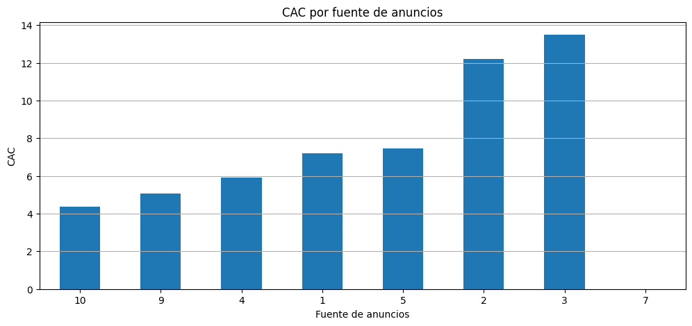

```python
# Calcular CAC por fuente

# Combinar gasto y número de clientes
cac_by_source = pd.DataFrame({
    'marketing_cost': costs_by_source,
    'customers': customers_by_source
})

# Calcular CAC
cac_by_source['cac'] = (
    cac_by_source['marketing_cost'] /
    cac_by_source['customers']
)

display(cac_by_source.sort_values('cac'))

# Grafico
cac_by_source['cac'].sort_values().plot(
    kind='bar',
    figsize=(12, 5)
)

plt.title('CAC por fuente de anuncios')
plt.xlabel('Fuente de anuncios')
plt.ylabel('CAC')
plt.xticks(rotation=0)
plt.grid(axis='y')
plt.show()
```

Interpretación del CAC

El CAC indica cuánto dinero debe invertir Showz en marketing para adquirir un cliente.

Un CAC bajo es favorable porque significa que la empresa puede adquirir clientes gastando menos dinero.

Sin embargo, el CAC por sí solo no permite determinar qué fuente es más rentable. Una fuente puede tener un CAC relativamente alto pero generar clientes con un LTV mucho mayor.

Por esta razón, compararemos el CAC con los ingresos y el LTV mediante el ROMI.

```python
# ROMI — Retorno de la inversión en marketing
# ROMI = (Ingresos generados por marketing - Gasto de marketing)/ Gasto de marketing

# Añadir la fuente de adquisición a cada pedido
orders_source = orders.merge(
    first_visit_source,
    on='uid',
    how='left'
)

display(orders_source.head())
```

|  | buy_ts | revenue | uid | order_month | source_id |
| --- | --- | --- | --- | --- | --- |
| 0 | 2017-06-01 00:10:00 | 17.00 | 10329302124590727494 | 2017-06-01 | 1 |
| 1 | 2017-06-01 00:25:00 | 0.55 | 11627257723692907447 | 2017-06-01 | 2 |
| 2 | 2017-06-01 00:27:00 | 0.37 | 17903680561304213844 | 2017-06-01 | 2 |
| 3 | 2017-06-01 00:29:00 | 0.55 | 16109239769442553005 | 2017-06-01 | 2 |
| 4 | 2017-06-01 07:58:00 | 0.37 | 14200605875248379450 | 2017-06-01 | 3 |

**Comentario del revisor**

**Éxito** - El análisis del CAC está correctamente planteado. Asignaste a cada cliente su fuente de adquisición a partir de la primera visita, calculaste el número de clientes por fuente y relacionaste esta información con el gasto de marketing para obtener el CAC correspondiente. Además, la interpretación reconoce correctamente que un CAC menor no implica por sí solo una mayor rentabilidad.

```python
# Ingresos generados por cada fuente
revenue_by_source = (
    orders_source.groupby('source_id')['revenue']
    .sum()
    .sort_values(ascending=False)
)

display(revenue_by_source)
```

```
source_id
4     56696.83
3     54511.24
5     52624.02
2     46923.61
1     31090.55
9      5759.40
10     4450.33
7         1.22
Name: revenue, dtype: float64
```

```python
# Calcular ROMI
# Crear tabla para calcular ROMI
romi_by_source = pd.DataFrame({
    'marketing_cost': costs_by_source,
    'revenue': revenue_by_source
})

# Calcular ROMI
romi_by_source['romi'] = (
    (romi_by_source['revenue'] - romi_by_source['marketing_cost'])
    / romi_by_source['marketing_cost']
)

display(romi_by_source.sort_values('romi', ascending=False))
```

| source_id | marketing_cost | revenue | romi |
| --- | --- | --- | --- |
| 1 | 20833.27 | 31090.55 | 0.492351 |
| 2 | 42806.04 | 46923.61 | 0.096191 |
| 9 | 5517.49 | 5759.40 | 0.043844 |
| 5 | 51757.10 | 52624.02 | 0.016750 |
| 4 | 61073.60 | 56696.83 | -0.071664 |
| 10 | 5822.49 | 4450.33 | -0.235665 |
| 3 | 141321.63 | 54511.24 | -0.614275 |
| 7 | NaN | 1.22 | NaN |

```python
# ROMI expresado en porcentaje
romi_by_source['romi_pct'] = romi_by_source['romi'] * 100

display(
    romi_by_source
    .sort_values('romi_pct', ascending=False)
)
```

| source_id | marketing_cost | revenue | romi | romi_pct |
| --- | --- | --- | --- | --- |
| 1 | 20833.27 | 31090.55 | 0.492351 | 49.235094 |
| 2 | 42806.04 | 46923.61 | 0.096191 | 9.619133 |
| 9 | 5517.49 | 5759.40 | 0.043844 | 4.384421 |
| 5 | 51757.10 | 52624.02 | 0.016750 | 1.674978 |
| 4 | 61073.60 | 56696.83 | -0.071664 | -7.166386 |
| 10 | 5822.49 | 4450.33 | -0.235665 | -23.566550 |
| 3 | 141321.63 | 54511.24 | -0.614275 | -61.427532 |
| 7 | NaN | 1.22 | NaN | NaN |

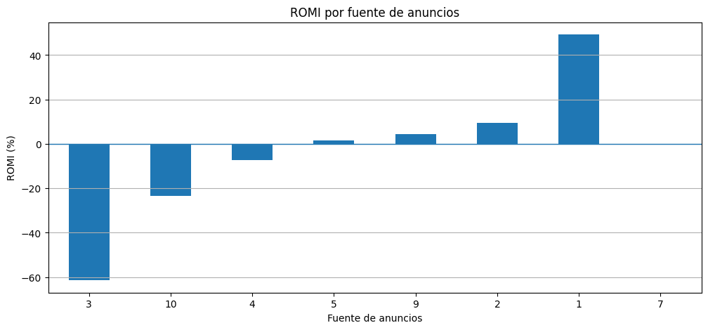

```python
# Gráfico del ROMI
romi_by_source['romi_pct'].sort_values().plot(
    kind='bar',
    figsize=(12, 5)
)

plt.title('ROMI por fuente de anuncios')
plt.xlabel('Fuente de anuncios')
plt.ylabel('ROMI (%)')
plt.xticks(rotation=0)
plt.axhline(0, linewidth=1)
plt.grid(axis='y')
plt.show()
```

```python
# Crear tabla resumen de las métricas de marketing

marketing_summary = pd.DataFrame({
    'marketing_cost': costs_by_source,
    'customers': customers_by_source,
    'cac': cac_by_source['cac'],
    'revenue': revenue_by_source,
    'romi_pct': romi_by_source['romi_pct']
})

# Ordenar por ROMI de mayor a menor
marketing_summary = marketing_summary.sort_values(
    'romi_pct',
    ascending=False
)

display(marketing_summary.round(2))
```

| source_id | marketing_cost | customers | cac | revenue | romi_pct |
| --- | --- | --- | --- | --- | --- |
| 1 | 20833.27 | 2899 | 7.19 | 31090.55 | 49.24 |
| 2 | 42806.04 | 3506 | 12.21 | 46923.61 | 9.62 |
| 9 | 5517.49 | 1088 | 5.07 | 5759.40 | 4.38 |
| 5 | 51757.10 | 6931 | 7.47 | 52624.02 | 1.67 |
| 4 | 61073.60 | 10296 | 5.93 | 56696.83 | -7.17 |
| 10 | 5822.49 | 1329 | 4.38 | 4450.33 | -23.57 |
| 3 | 141321.63 | 10473 | 13.49 | 54511.24 | -61.43 |
| 7 | NaN | 1 | NaN | 1.22 | NaN |

```python
# Fuente con ROMI más alto y más bajo

source_highest_romi = marketing_summary['romi_pct'].idxmax()
highest_romi = marketing_summary['romi_pct'].max()

source_lowest_romi = marketing_summary['romi_pct'].idxmin()
lowest_romi = marketing_summary['romi_pct'].min()

print('Fuente con ROMI más alto:', source_highest_romi)
print('ROMI más alto:', round(highest_romi, 2), '%')

print('\nFuente con ROMI más bajo:', source_lowest_romi)
print('ROMI más bajo:', round(lowest_romi, 2), '%')
```

```
Fuente con ROMI más alto: 1
ROMI más alto: 49.24 %

Fuente con ROMI más bajo: 3
ROMI más bajo: -61.43 %
```

```python
# Fuente con CAC más bajo y más alto

source_lowest_cac = marketing_summary['cac'].idxmin()
lowest_cac = marketing_summary['cac'].min()

source_highest_cac = marketing_summary['cac'].idxmax()
highest_cac = marketing_summary['cac'].max()

print('Fuente con CAC más bajo:', source_lowest_cac)
print('CAC más bajo:', round(lowest_cac, 2))

print('\nFuente con CAC más alto:', source_highest_cac)
print('CAC más alto:', round(highest_cac, 2))
```

```
Fuente con CAC más bajo: 10
CAC más bajo: 4.38

Fuente con CAC más alto: 3
CAC más alto: 13.49
```

Conclusión de la Actividad IV - Marketing

El análisis de marketing permitió comparar el gasto realizado por Showz con el número de clientes adquiridos, el costo de adquisición (CAC) y la rentabilidad de cada fuente mediante el ROMI.

Los resultados muestran diferencias importantes entre las fuentes de adquisición. La fuente 10 presenta el CAC más bajo, con un valor de 4.38, lo que indica que es la fuente que requiere menor inversión para adquirir un cliente.

Por otro lado, la fuente 3 presenta el CAC más alto, con un valor de 13.49, y también registra el ROMI más bajo, de -61.43 %. Esto indica que esta fuente es poco eficiente, ya que el costo de adquisición es elevado y los ingresos generados no compensan la inversión realizada.

Por lo tanto, se recomienda priorizar las fuentes que combinen un CAC bajo con un ROMI positivo y reducir o revisar la inversión en las fuentes que presenten un CAC elevado y un ROMI negativo.

Sin embargo, el CAC no debe utilizarse como única métrica para tomar la decisión. También es necesario considerar el LTV de los clientes adquiridos por cada fuente, ya que una fuente con un CAC mayor puede resultar rentable si consigue clientes que generan mayores ingresos a largo plazo.

En conclusión, la estrategia de marketing debe concentrar progresivamente el presupuesto en las fuentes con mejor relación entre costo de adquisición, valor generado por los clientes y rentabilidad, mientras se revisan aquellas fuentes que generan pérdidas.

Conclusión final y recomendaciones de marketing

Después de analizar el comportamiento de los usuarios, las ventas y los gastos de marketing, se recomienda concentrar la inversión en las fuentes de adquisición que presenten la mejor combinación de bajo CAC, alto LTV y ROMI positivo.

La fuente 10 destaca por presentar el CAC más bajo, con un valor de 4.38, por lo que representa una opción eficiente para adquirir nuevos clientes. Por el contrario, la fuente 3 presenta el CAC más alto, con 13.49, y el ROMI más bajo, con -61.43 %, lo que indica que la inversión realizada en esta fuente no resulta rentable.

La decisión de inversión debe basarse principalmente en la relación entre CAC, LTV y ROMI. El objetivo es invertir más en las fuentes que generan clientes rentables a largo plazo y reducir el presupuesto destinado a aquellas que no recuperan la inversión.

En conclusión, Showz debería redistribuir progresivamente su presupuesto hacia las fuentes con CAC bajo, LTV alto y ROMI positivo, y disminuir la inversión en las fuentes con CAC elevado y ROMI negativo. Esta estrategia permitiría utilizar el presupuesto de marketing de manera más eficiente y mejorar la rentabilidad de la empresa.

**Comentario del revisor**

**Éxito** - El análisis de marketing está bien desarrollado. Calculaste el CAC y el ROMI por fuente, comparaste los resultados y construiste una tabla resumen que facilita identificar las fuentes con mejor y peor desempeño. También interpretaste correctamente que la fuente 3 presenta una combinación desfavorable de CAC alto y ROMI negativo.